# 14imgproc

https://colab.research.google.com/drive/1rtW_k77KPXxlVNdhjuZR-MFPY_8M76s_?usp=sharing

```python
!curl -o test.png https://i.hizliresim.com/qohz8m6.png
```

```
  % Total    % Received % Xferd  Average Speed   Time    Time     Time  Current
                                 Dload  Upload   Total   Spent    Left  Speed
100  119k    0  119k    0     0   336k      0 --:--:-- --:--:-- --:--:--  336k
```

```python
#!pip install nbconvert
!jupyter nbconvert --to html 14imgproc.ipynb
```

```python
import numpy as np
import matplotlib.pyplot as plt
import cv2 as cv

from google.colab.patches import cv2_imshow as cim
```

## On Isleme

- Gri seviyedeki ekmek goruntusunde, gozeneklerin belirgin olmasi  
  icin histogram germe islemi uygulanir.
- Histogram germe islemi, histogrami genis bolgeye yayar. Bu sayede goruntulerin kontrasti iyilestirilmis olur. Histogram germe ile histogram esitleme farkliliklari olsada benzerdir.
- Asagidaki goruntuye histogram esitleme uygulayalim ve sonuclari gorelim.

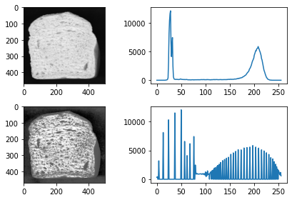

```python
timg = cv.imread("test.png")
img = cv.cvtColor(timg, cv.COLOR_BGR2GRAY)

fig, axs = plt.subplots(2, 2)

hist = cv.calcHist([img], [0], None, [256], [0, 256])
axs[0, 0].imshow(img, cmap='gray')
axs[0, 1].plot(hist)

img2 = cv.equalizeHist(img)
hist2 = cv.calcHist([img2], [0], None, [256], [0, 256])
axs[1, 0].imshow(img2, cmap='gray')
axs[1, 1].plot(hist2)

plt.tight_layout()
plt.plot();
```

- Ciktiya baktigimizda, ekmegin yuzeyi acik renk, ekmegin gozenekleri ise koyu renkte oldugu goruluyor.
- Bu adim ile birlikte on isleme asamalari bitmis oluyor.

## Goruntu Isleme

- Bu kisimda islemeye hazir hale gelen goruntuler **OTSU** yontemiyle esiklenerek ikili goruntu haline donusturulecektir. Bu yontemler asagidaki diyagramda gosterilmistir.

[figure not shown]

- **OTSU**, gri seviyede goruntu uzerinde uygulanan **esik belirleme** yontemidir. Bu yontem bir goruntudeki pikselleri farkli siniflara ayirir.
- Bu ornekte, $M*N$ lik bir goruntunun arka plan ve on plan seklinde iki sinifa ayrildigi varsayilmaktadir.
- Siniflar arasi varyans $J(t) = σ_0 + σ_1$ ile tanimlanir
- Her bir sinifin varyansi ise asagidaki esitlikler ile tanimlanir.
  - $σ_0 = ω_0(\mu_0-\mu_t)^2$
  - $σ_1 = ω_1(\mu_1-\mu_t)^2$
    - $ω_i$ : Sinifin yogunlugu
    - $μ_i$ :Sinifin agirlik ortalamasi
    - $μ_t$: Goruntunun ortalamasi
- Bu varyans degerlerini asagidaki esitlikler ile hesaplariz:
  - $ω_0, μ_0$ icin
    - $ω_0 = Σ_\{i=0\}^\{t-1\} p_i$
    - $\mu_0 = Σ_\{i=0\}^\{t-1\}p_i·X(i)$
  - $ω_1, μ_1$ icin
    - $ω_1 = Σ_\{i=t\}^\{mn-1\} p_i$
    - $\mu_1 = Σ_\{i=t\}^\{mn-1\}p_i·X(i)$
- $p_i$, $i$ tonunun gelme olasiligidir
- $X(i)$ $i.$ renk seviyesidir.
- Goruntunun ortalamasi ise;
  - $μ_T = Σ_\{i=0\}^\{mn-1\}p_i·X(i)$

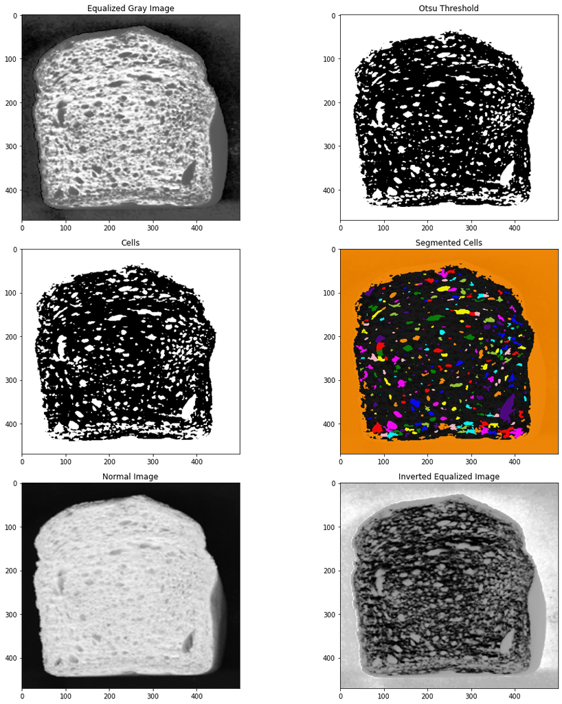

```python
# https://scikit-image.org/docs/dev/auto_examples/applications/plot_human_mitosis.html

from scipy import ndimage as ndi
from skimage import (
    color, feature, filters, measure, segmentation
)

def crop(img, sl=5):
    img = img.copy()
    w, h = img.shape
    q1, q2 = w//sl, h//sl

    return img[q1:w-q1, q2:h-q2]

# Otsu Thresholding
def doOtsuThresholding(img, classes=2):
    th = filters.threshold_multiotsu(img, classes=classes)
    regions = np.invert(np.digitize(img, bins=th))

    return th, regions

# Cell Labeling
def doCellLabeling(img):
    cells = np.invert(img > th[0])
    labeled_cells = measure.label(cells)

    """ https://en.wikipedia.org/wiki/Distance_transform
        On yuz piksellerin, arka yuz piksellerine olan uzakligini verir"""
    distance = ndi.distance_transform_edt(cells)
    local_max_coords = feature.peak_local_max(distance, min_distance=8)
    local_max_mask = np.zeros(distance.shape, dtype=bool)
    local_max_mask[tuple(local_max_coords.T)] = True
    markers = measure.label(local_max_mask)
    segmented_cells = segmentation.watershed(-distance, markers, mask=cells)
    color_labels = color.label2rgb(segmented_cells, img, alpha=0.9, bg_label=0)

    return cells, segmented_cells, color_labels

cimg = img2.copy() #crop(img2)
th, regions = doOtsuThresholding(cimg)
cells, segmented_cells, color_labels  = doCellLabeling(cimg)

# Outputs
fig, ax = plt.subplots(3, 2, figsize=(15, 15))

ax[0, 0].imshow(img2, cmap='gray')
ax[0, 0].set_title('Equalized Gray Image')

ax[0, 1].imshow(regions, cmap='gray')
ax[0, 1].set_title('Otsu Threshold')

ax[1, 0].imshow(cells, cmap='gray')
ax[1, 0].set_title('Cells')

ax[1, 1].imshow(color_labels, cmap='gray')
ax[1, 1].set_title('Segmented Cells')

ax[2, 0].imshow(img, cmap='gray')
ax[2, 0].set_title('Normal Image')

ax[2, 1].imshow(np.invert(img2), cmap='gray')
ax[2, 1].set_title('Inverted Equalized Image')

plt.tight_layout()
plt.show()
```

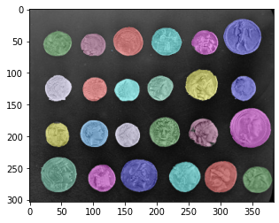

[figure not shown]

```python
import numpy as np
import matplotlib.pyplot as plt
import cv2 as cv

from skimage import data, io, feature, morphology, filters, measure, segmentation, color
from scipy import ndimage
from google.colab.patches import cv2_imshow as cim

coins = data.coins()
#blur = cv.GaussianBlur(img, ksize=(5, 5), sigmaX=0)
#cim(blur)
#eroded = cv.erode(blur, kernel=(3, 3), iterations=2)

edges = np.uint8(filters.sobel(coins)*255)
markers = np.zeros_like(coins)
x, y = 1, 2
markers[coins < 30.] = y
markers[coins > 150.] = x

ws = segmentation.watershed(edges, markers)

seg1 = measure.label(ws == x)
expanded = segmentation.expand_labels(seg1, distance=2)

color1 = color.label2rgb(seg1, image=coins, bg_label=0)
plt.figure(0)
plt.imshow(color1[..., ::-1])

color2 = color.label2rgb(expanded, image=coins, bg_label=0)
plt.figure(1)
plt.imshow(color2[..., ::-1])
```

```
ORIGINAL
```

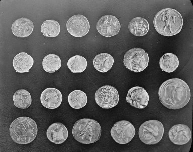

```
GAUSSIAN
```

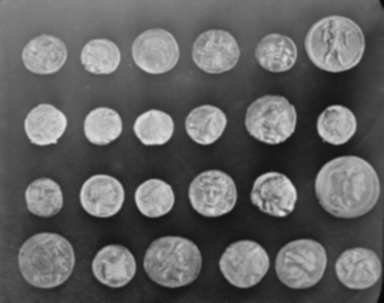

```
THRESH_TRUNC
```

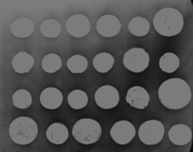

```
DILATED
```

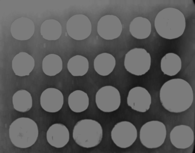

```
CANNY
```

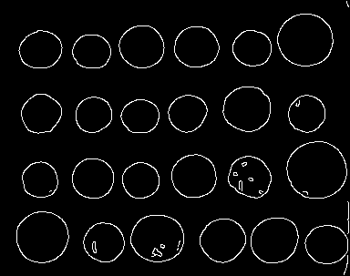

```python
def createGaussianKernel(size: int, sigma: int = 1):
    """
        size    Kernel size
        sigma   Standard deviation of the Normal (a.k.a Gaussian) Distribution.
                default value = 1 because we will create symmetric distribution.
    """
    size //= 2

    x, y = np.mgrid[-size:size+1, -size:size+1]
    variance = sigma**2

    return 1 / (2*np.pi*variance) * np.exp(-((x**2 + y**2) / 2*sigma**2))

def doGaussianBlur(img: np.ndarray, kernel: np.ndarray):
    return cv.filter2D(img, -1, kernel)

coins = data.coins()
#kernel = createGaussianKernel(5, sigma=1)
#blured_img = doGaussianBlur(img, kernel)
blured_img = cv.GaussianBlur(coins, ksize=(5, 5), sigmaX=0)
ret, thresh = cv.threshold(blured_img, 123, 255, cv.THRESH_TRUNC)
dilate = cv.dilate(thresh, kernel=(3, 3), iterations=5)
canny_img = np.uint8(feature.canny(thresh)*255)

print("ORIGINAL")
cim(coins)

print("GAUSSIAN")
cim(blured_img)

print("THRESH_TRUNC")
cim(thresh)

print("DILATED")
cim(dilate)

print("CANNY")
cim(canny_img)
```